# Practical Machine Learning Course Project

P. Baine

January 8, 2018

## Overview

What you should submit The goal of your project is to predict the manner in which they did the exercise. This is the “classe” variable in the training set. You may use any of the other variables to predict with. You should create a report describing how you built your model, how you used cross validation, what you think the expected out of sample error is, and why you made the choices you did. You will also use your prediction model to predict 20 different test cases.

Peer Review Portion Your submission for the Peer Review portion should consist of a link to a Github repo with your R markdown and compiled HTML file describing your analysis. Please constrain the text of the writeup to < 2000 words and the number of figures to be less than 5. It will make it easier for the graders if you submit a repo with a gh-pages branch so the HTML page can be viewed online (and you always want to make it easy on graders :-).

Course Project Prediction Quiz Portion Apply your machine learning algorithm to the 20 test cases available in the test data above and submit your predictions in appropriate format to the Course Project Prediction Quiz for automated grading.

## Creating the Random Forest Model

First load in the packages and the data.

```r
library(data.table)
library(tidyverse)
library(caret)
library(dplyr)
library(randomForest)
trainingraw <- fread("pml-training.csv")
testingraw <- fread("pml-testing.csv")
```

The timestamps and identity variables will not be used in the model, so they are removed from the data. Several of the columns contain mostly NA values or blanks for their observations, so these columns are also removed from the data. I set the threshold to filter down to only columns with less than 10% of NAs or blanks.

```r
training <- select(trainingraw, -c(V1, user_name, raw_timestamp_part_1, raw_timestamp_part_2, cvtd_timestamp, new_window,num_window))
testing <- select(testingraw, -c(V1, user_name, raw_timestamp_part_1, raw_timestamp_part_2, cvtd_timestamp, new_window,num_window))
training <- training[,colMeans(is.na(training)) <= .1, with = FALSE]
training <- training[,colMeans(training == "", na.rm = TRUE) <= .1, with = FALSE]
testing <- testing[,colMeans(is.na(testing)) <= .1, with = FALSE]
testing <- testing[,colMeans(testing == "", na.rm = TRUE) <= .1, with = FALSE]
```

The result is two cleaned data sets with 53 columns each. The cleaned training data will then need to be partitioned for cross validation. The data is partitioned into two groups, 75% of the data will be used to train while the other 25% will be used to test the model.

```r
set.seed(12345)
inTrain <- createDataPartition(training$classe, p = .75, list = FALSE)
traindat <- training[inTrain,]
testdat <- training[-inTrain,]
```

With the training data from the partition, I use the random forest method to train the model.

```r
rfControl <- trainControl(method = "boot", number = 10)
rfmodel <- train(classe~., data = traindat, method = "rf", prox = TRUE, ntree = 100, trControl = rfControl)
```

## Evaluating the Model

The next step is to evaluate the performance of the models against the validation set using the predict function. Below is the confusion matrix which tests the accuracy of the model against the cross validation set.

```r
rfeval <- predict(rfmodel, testdat)
confusionMatrix(rfeval, testdat$classe)
```

```
## Confusion Matrix and Statistics
##
##           Reference
## Prediction    A    B    C    D    E
##          A 1394   10    0    0    0
##          B    1  934    4    0    0
##          C    0    5  847    8    2
##          D    0    0    4  796    6
##          E    0    0    0    0  893
##
## Overall Statistics
##
##                Accuracy : 0.9918
##                  95% CI : (0.9889, 0.9942)
##     No Information Rate : 0.2845
##     P-Value [Acc > NIR] : < 2.2e-16
##
##                   Kappa : 0.9897
##  Mcnemar's Test P-Value : NA
##
## Statistics by Class:
##
##                      Class: A Class: B Class: C Class: D Class: E
## Sensitivity            0.9993   0.9842   0.9906   0.9900   0.9911
## Specificity            0.9972   0.9987   0.9963   0.9976   1.0000
## Pos Pred Value         0.9929   0.9947   0.9826   0.9876   1.0000
## Neg Pred Value         0.9997   0.9962   0.9980   0.9980   0.9980
## Prevalence             0.2845   0.1935   0.1743   0.1639   0.1837
## Detection Rate         0.2843   0.1905   0.1727   0.1623   0.1821
## Detection Prevalence   0.2863   0.1915   0.1758   0.1644   0.1821
## Balanced Accuracy      0.9982   0.9915   0.9935   0.9938   0.9956
```

## Testing

This model is then used to predict the 20 classe variables in the testing data. The results of my prediction using the random forest model are:

```r
data.frame(Problem = testing$problem_id, Prediction = c(as.character(predict(rfmodel, testing))))
```

```
##    Problem Prediction
## 1        1          B
## 2        2          A
## 3        3          B
## 4        4          A
## 5        5          A
## 6        6          E
## 7        7          D
## 8        8          B
## 9        9          A
## 10      10          A
## 11      11          B
## 12      12          C
## 13      13          B
## 14      14          A
## 15      15          E
## 16      16          E
## 17      17          A
## 18      18          B
## 19      19          B
## 20      20          B
```

### Appendix: Visualizations

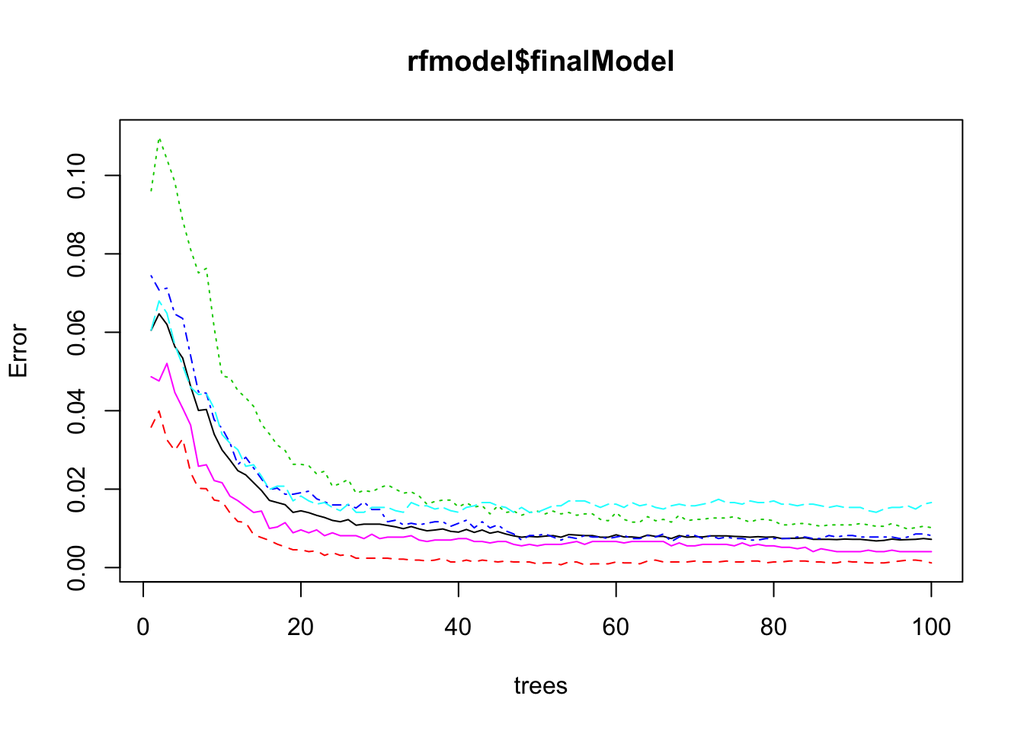

```r
plot(rfmodel$finalModel)
```

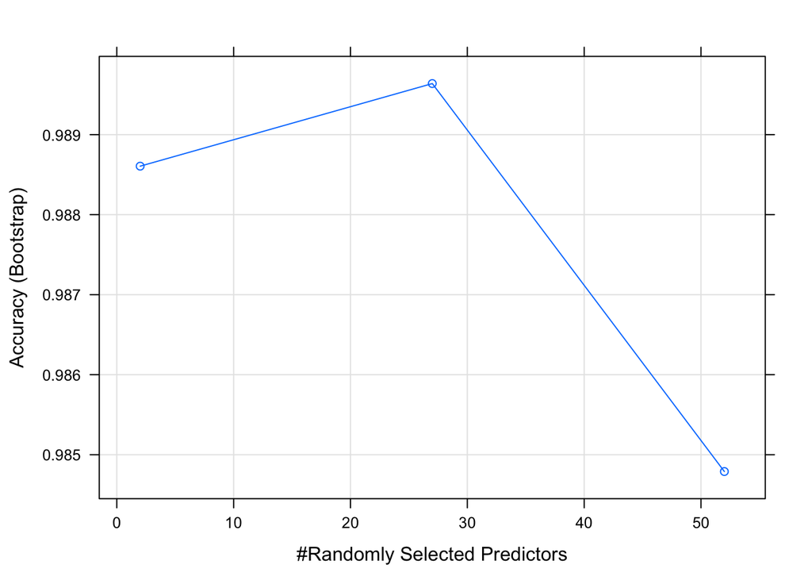

```r
plot(rfmodel)
```